# Visualización en ggplot2

# La gramática de las gráficas

Es una herramienta que nos permite:

- Describir los componentes de una gráfica en forma concisa
- Ir más allá de los nombres de la gráfica (e.g. scatterplot, boxplot, etc.)
- Entender la estructura detrás de los gráficos estadísticos

Héroes de trabajos en la gramática de las gráficas:

## ¿Qué es?

Es una abstracción que nos permite describir cómo crear gráficos ricos e informativos. Una gramática permite que pensemos que dos gráficos distintos comparten una estructura común. Además, tenerlo en un paquete permite que los usuarios no se limiten únicamente a los gráficos específicos que se implementan paquete a paquete.

## Características importantes

Los componentes de una gráfica son ortogonales:

```
- Cambiar uno no debe romper los otros
- Una configuración distinta de componentes es válida
- Puedes construir mayor complejidad agregando capas
```

# ggplot

**Aquí empieza el pocheo necesario. Es más fácil si saben cómo se llama en inglés**.

Los componentes de la gramática de gráficas específica para ggplot son:

1. Una o más capas:
   1. Datos y *aesthetic mappings*
   2. UNa transformación estadística
   3. Un objeto geométrico
   4. Ajustes en las posiciones de los objetos
2. Una escala para cada estética
3. Un sistema de coordenadas
4. Una especificación de facetas

## Base plotting

```r
str(diamonds)
```

```
## Classes 'tbl_df', 'tbl' and 'data.frame':    53940 obs. of  10 variables:
##  $ carat  : num  0.23 0.21 0.23 0.29 0.31 0.24 0.24 0.26 0.22 0.23 ...
##  $ cut    : Ord.factor w/ 5 levels "Fair"<"Good"<..: 5 4 2 4 2 3 3 3 1 3 ...
##  $ color  : Ord.factor w/ 7 levels "D"<"E"<"F"<"G"<..: 2 2 2 6 7 7 6 5 2 5 ...
##  $ clarity: Ord.factor w/ 8 levels "I1"<"SI2"<"SI1"<..: 2 3 5 4 2 6 7 3 4 5 ...
##  $ depth  : num  61.5 59.8 56.9 62.4 63.3 62.8 62.3 61.9 65.1 59.4 ...
##  $ table  : num  55 61 65 58 58 57 57 55 61 61 ...
##  $ price  : int  326 326 327 334 335 336 336 337 337 338 ...
##  $ x      : num  3.95 3.89 4.05 4.2 4.34 3.94 3.95 4.07 3.87 4 ...
##  $ y      : num  3.98 3.84 4.07 4.23 4.35 3.96 3.98 4.11 3.78 4.05 ...
##  $ z      : num  2.43 2.31 2.31 2.63 2.75 2.48 2.47 2.53 2.49 2.39 ...
```

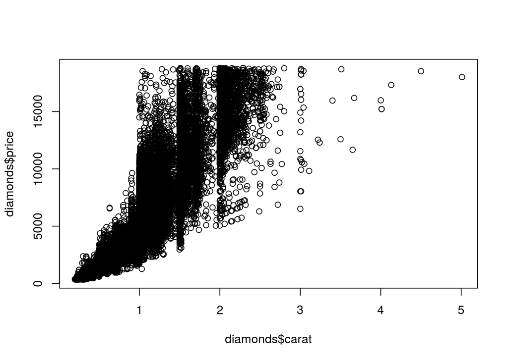

```r
plot(diamonds$carat, diamonds$price)
```

Buen primer intento pero… algo feo… y limitado.

## Primer ejemplo en ggplot

```r
ggplot() +
  layer(
    data = diamonds,
    mapping = aes(x = carat, y = price),
    geom = "point",
    stat = "identity",
    position = "identity") +
  scale_y_continuous() +
  scale_x_continuous() +
  coord_cartesian()
```

[output not shown]

Si conoces los `defaults` del paquete, puedes escribir las cosas de manera aun mas simple…

```r
ggplot(diamonds, aes(carat, price)) + geom_point()
```

[output not shown]

o aun mas abreviado… con el magnifico `qplot`

```r
qplot(data = diamonds, x = carat, y = price, geom = "point")
```

[output not shown]

# Las capas

`ggplot` produce un objeto que se puede convertir en una gráfica. Es decir, `R` sabe cómo convertirlo en una gráfica.

Este objeto está formado por capas, mismas que tienen sus entradas (*inputs*) particulares y que comparten argumentos del gráfico `base` generado por `ggplot()`. Con el operador `+` se van agregando las distintas capas al mismo objeto.

Así como en otros casos, el objeto en `R` puede ser guardado en una variable, se le puede imprimir, se le puede guardar como imagen de diferentes formatos, o se puede guardar en una lista o en un `Rdata`.

## Componentes de una capa

### Datos y mapa estético

Permite mapear las columnas del `data.frame` de entrada a los aspectos de la grafica.

Es decir,

- las coordenadas x, y
- el tamaño
- el color
- el relleno
- las agrupaciones

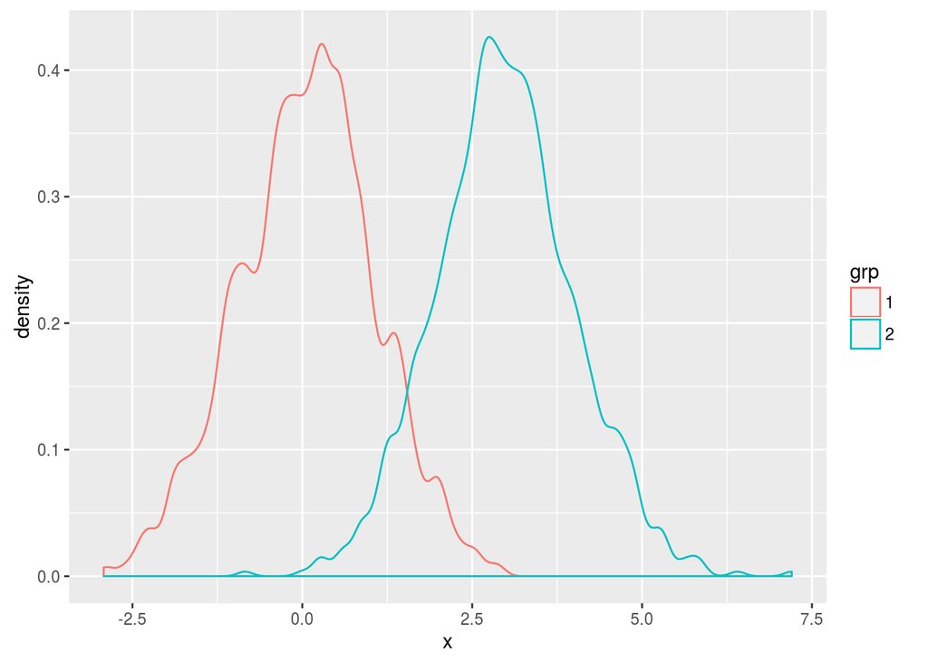

```r
mix2norm <- data.frame(x  = c(rnorm(1000), rnorm(1000, 3)),
                       grp = as.factor(rep(c(1,2),each=1000)))

ggplot(mix2norm, aes(x=x, color = grp)) + geom_density(adjust = 1/2)
```

### Transformaciones estadísticas

Ésta puede ser, por ejemplo, un resumen del input recibido; se especifica vía el comando `stat`. Ejemplos:

- binning
- smoothing
- boxplot
- identity

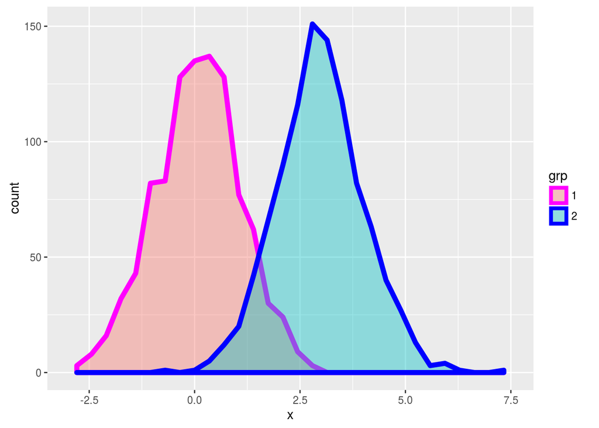

```r
ggplot(mix2norm, aes(x=x, color = grp, fill= grp)) +
  geom_density(alpha = .4, size = 2, stat = "bin") +
  scale_color_manual(values = c("1" = "magenta", "2" = "blue"))
```

Horrible pero… ¡ilustra el control que te da!

### El objeto geométrico

Esto permite especificar el tipo de gráfico a crear. Se especifica a partir vía la `geom`. Se define de acuerdo a su dimensión, es decir,

- `0-dim`: puntos, texto
- `1-dim`: líneas
- `2-dim`: polígonos, intervalos

Otras geometrías incluyen:

- `geom_hist`
- `geom_bar`
- `geom_contour`
- `geom_line`
- `geom_density`

`geom_density` por ejemplo utiliza `ribbon` o una cosa que a veces encontrarán en español como violín (no pun intended).

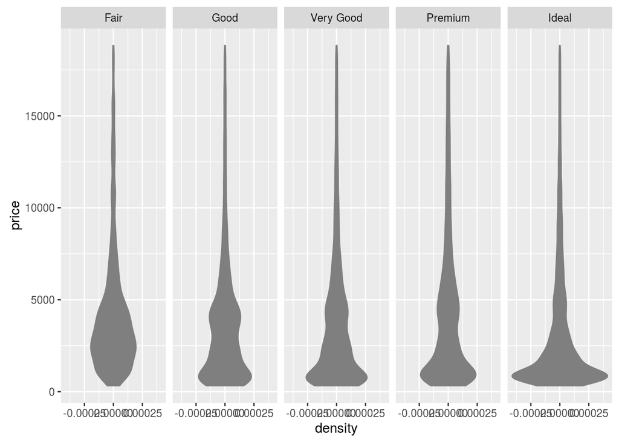

```r
ggplot(diamonds, aes(x = price)) +
  stat_density(aes(ymax = ..density..,  ymin = -..density..),
    fill = "grey50", colour = "grey50",
    geom = "ribbon", position = "identity") +
  facet_grid(. ~ cut) +
  coord_flip()
```

Además, se puede cambiar la transformación estadística manteniendo la geometría fijada.

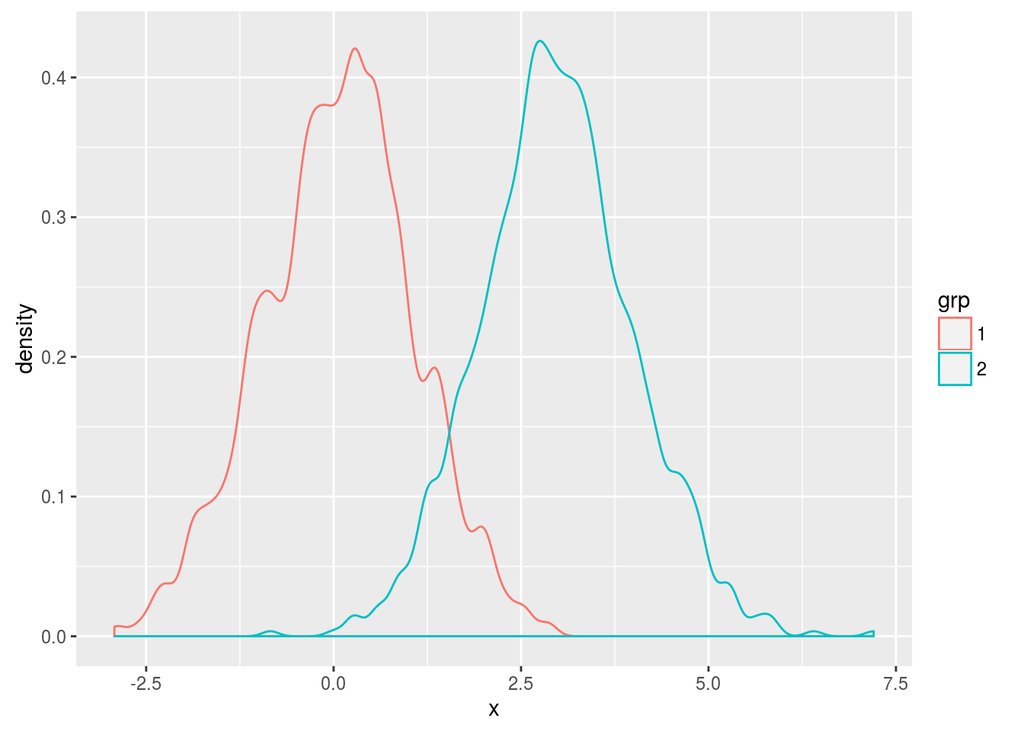

```r
ggplot(mix2norm, aes(x = x, color = grp)) + geom_density(adjust = 1/2)
```

Viceversa, puede cambiarse la geometría pero mantener la transformación estadística.

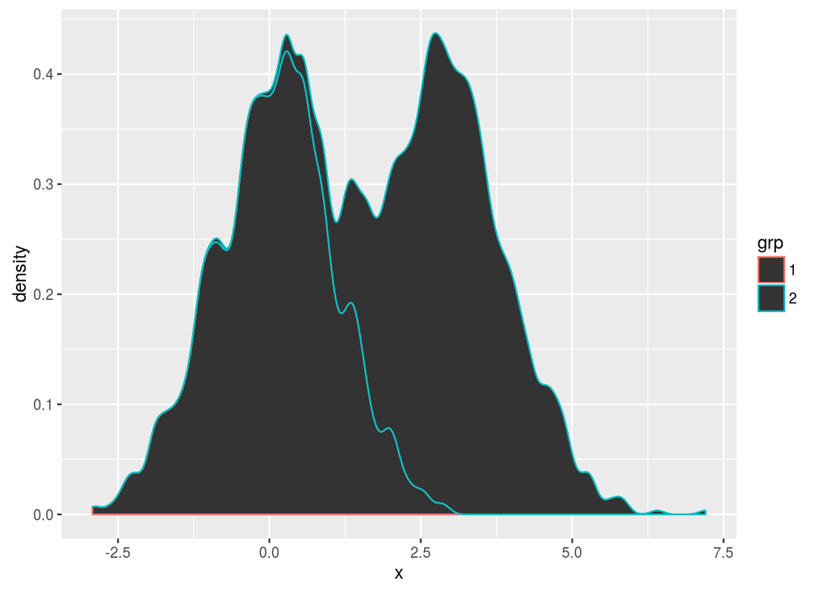

```r
ggplot(mix2norm, aes(x = x, color = grp)) + stat_density(adjust = 1/2)
```

Revisa el comando `position` y `geometry`.

Revisa sus defaults y juega con los ejemplos!

### Posición

Es posible especificar la posición de cada una de las capas en relación a otras. Ejemplos:

- `dodge`
- `identity`
- `jitter`

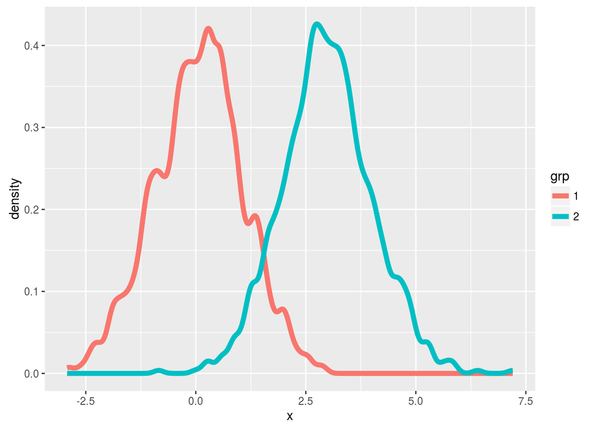

```r
ggplot(mix2norm, aes(x=x, color = grp)) +
  stat_density(adjust=1/2, size=2, position ="identity",geom ="line")
```

### Escalas

Determina cuál valor de entrada mapea a qué estética específica. Se escribe usando `scale`. Hay de todo:

- `continous`
- `logarithmic`
- `values to shapes`
- `what limits`
- `what labels`
- `what marks`

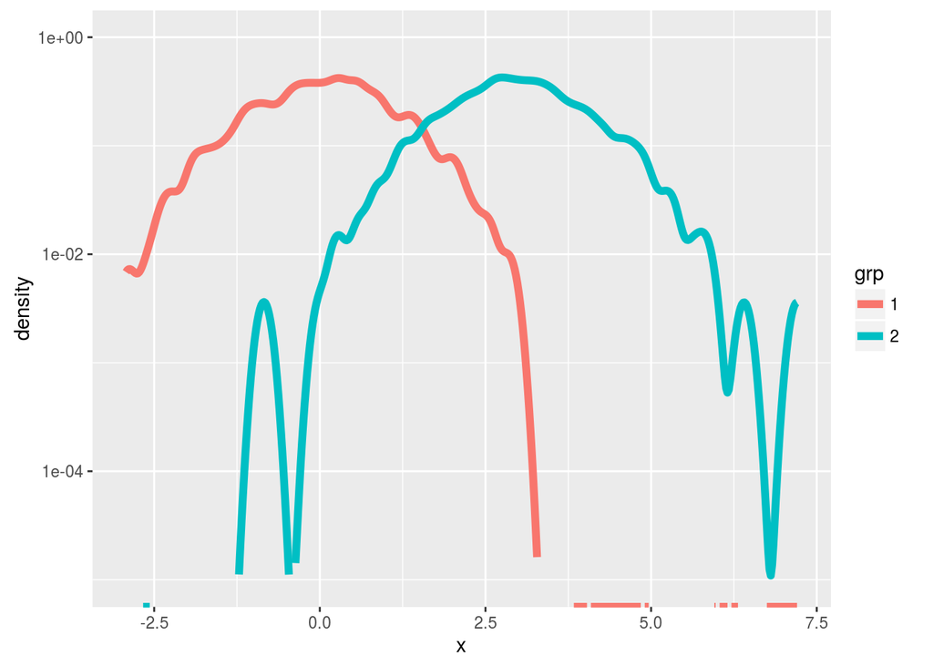

```r
ggplot(mix2norm, aes(x=x, color = grp)) +
  stat_density(adjust=1/2, size=2, position ="identity", geom ="line") +
  scale_y_log10(limits = c(1e-5,1))
```

### Coordenadas

Te permite especificar las posiciones de las cosas y cómo mapean a las posiciones en la pantalla. Antes todo era entorno a cómo le dices las cosas a R pero también importa cómo las ves. Coordenadas distintas pueden afectar a los objetos geométricos. Ejemplos:

- `cartesian`
- `polar`
- `map-projection`

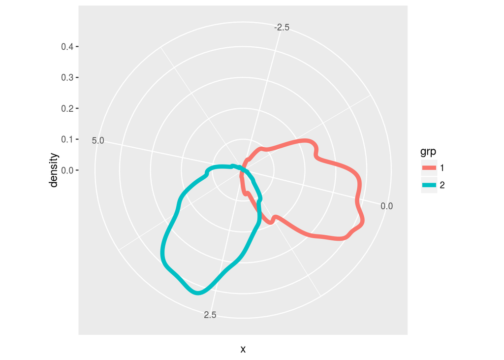

```r
ggplot(mix2norm, aes(x=x, color = grp)) +
  stat_density(adjust=1/2, size=2, position ="identity",geom ="line") +
  coord_polar()
```

### Facetas

Permite arreglar diferentes gráficas en un grid o panel.

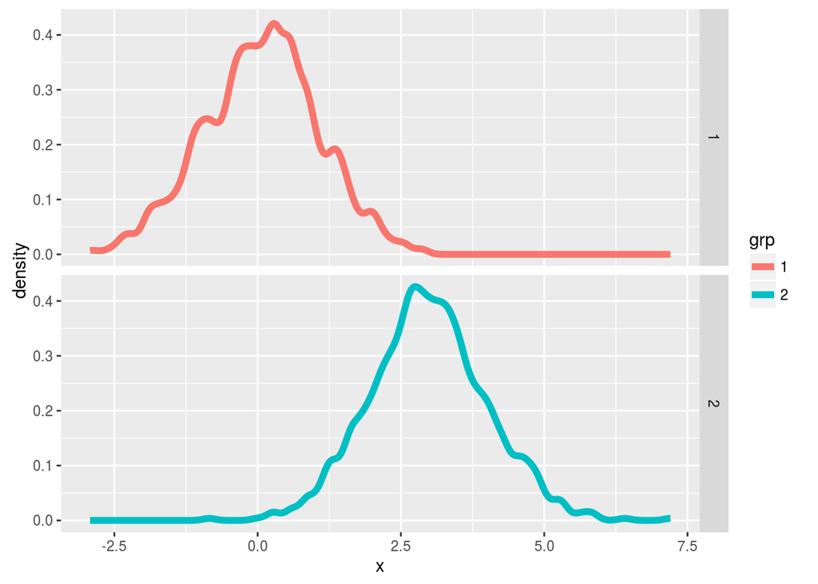

```r
ggplot(mix2norm, aes(x=x, color = grp)) +
  stat_density(adjust = 1/2, size = 2, position = "identity", geom = "line") +
  facet_grid(grp~.)
```

Ve el help de `facet_wrap`